# David Coit HW_4

David Coit

11/7/2019

## Homework

1. Compare the most important features from at least 2 different classes of feature selection methods covered in this tutorial with any reasonable machine learning dataset from mlbench. Do these feature selection methods provide similar results?
2. Attempt a feature selection method not covered in this tutorial (backward elimination, forward propogation, etc.)

### Question 1

**I chose to work with the Glass dataset from mlbench. Since it works with this assignment as a material identification task, it has at least tangential relevance to the class as a scientifc task. There are also enough predictor variables (9) to make some meaningful comparisons between feature selection methods.**

```r
# Load libraries
library(tidyverse)
library(caret)
library(randomForest)
library(mlbench)
library(glmnet)
library(corrplot)
library(foreign)
library(nnet)
library(LogicReg)
library(logicFS)
```

```r
# Clear workspace and import glass data set
rm(list = ls())
data(Glass)
```

```r
# Transform glass data set to make sure predictor variable values are numeric
glass_num = transform(Glass,
                      RI = as.numeric(RI),
                      Na = as.numeric(Na),
                      Mg = as.numeric(Mg),
                      Al = as.numeric(Al),
                      Si = as.numeric(Si),
                      K = as.numeric(K),
                      Ca = as.numeric(Ca),
                      Ba = as.numeric(Ba),
                      Fe = as.numeric(Fe),
                      Type = as.factor(Type)
                        )
# Check for NA values
any(is.na(glass_num))
```

```
## [1] FALSE
```

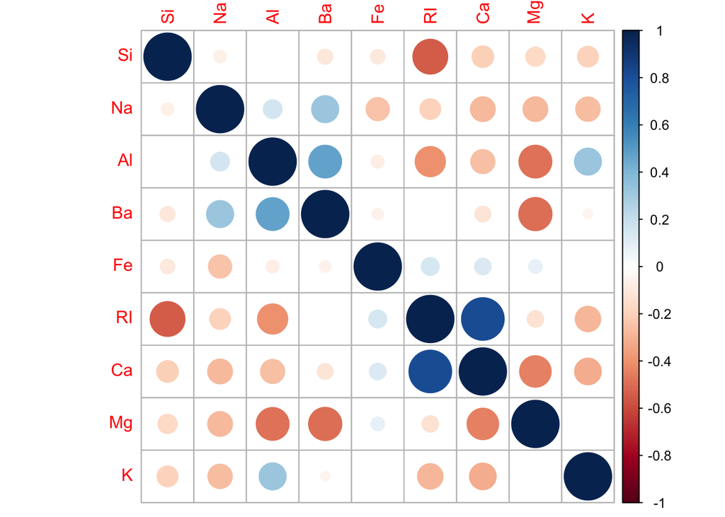

```r
# Check for variables in the dataset that are correlated
correlation_matrix = cor(glass_num[,1:9])
corrplot(correlation_matrix, order = "hclust")
```

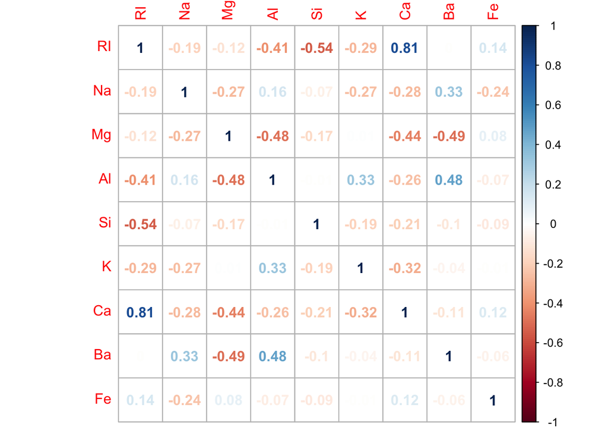

```r
corrplot(correlation_matrix, method = "number")
```

```r
highly_correlated <- colnames(glass_num[, -1])[findCorrelation(correlation_matrix, cutoff = 0.5, verbose = TRUE)]
```

```
## Compare row 7  and column  1 with corr  0.81
##   Means:  0.319 vs 0.217 so flagging column 7
## Compare row 1  and column  5 with corr  0.542
##   Means:  0.242 vs 0.206 so flagging column 1
## All correlations <= 0.5
```

**In the glass data, among the 9 predictor variables of glass type the variable refractive index does have correlation greater than 0.5 with two other variables - calcium and silicon. I am not sure why the output of the “highly_correlated” line says that all correlations are <=0.5 - when we display the actual values in the correlation plot we can plainly see the two values which exceed 0.5.**

```r
# Random forest feature importance
set.seed(1618)
train_size <- floor(0.75 * nrow(glass_num))
train_pos <- sample(seq_len(nrow(glass_num)), size = train_size)

train_classification <- glass_num[train_pos, ]
test_classification <- glass_num[-train_pos, ]

#fit a model
rfmodel = randomForest(Type ~ .,
                       data=train_classification,
                       importance = TRUE,
                       oob.times = 15,
                       confusion = TRUE,
                       )

# rank features based on importance
importance(rfmodel)
```

```
##            1         2         3          5          6         7
## RI 28.969640 20.714936  1.974601  2.7718469  7.4042694  7.278611
## Na  8.366773  7.651730  1.509268  6.4129545 13.9926161 12.349081
## Mg 25.024893 20.630595  7.769152 18.2653507 16.7044231 14.202265
## Al 20.897774 20.669009  4.228085  9.1120654 -1.1485223 13.848131
## Si 12.204545  7.915583 -1.501373  0.3363341  3.4846981  1.999418
## K  13.229149 13.115857  3.411077  1.9601922 17.7822923  6.635060
## Ca 16.025068 21.256951  3.398995 11.9559217 -0.1926577  5.369789
## Ba 11.167337  8.401500  3.560536  5.2517343  6.3924944 28.057840
## Fe  7.614146  5.010928  2.215075 -1.8024093  4.9785843  4.838759
##    MeanDecreaseAccuracy MeanDecreaseGini
## RI             32.04233        17.565142
## Na             17.71867        12.296457
## Mg             31.95226        17.661829
## Al             28.80843        17.518218
## Si             14.08923         8.795572
## K              23.46191        11.057249
## Ca             25.86562        14.728769
## Ba             24.51056         9.810914
## Fe             10.16935         6.047666
```

```r
# Check results on test set
predCheckResponse <- predict(rfmodel, test_classification, type = "response")


# Checking classification accuracy
# Generate confusion matrix
# Rows are predictions, columns are truth
table(predCheckResponse, test_classification$Type)
```

```
##
## predCheckResponse  1  2  3  5  6  7
##                 1 15  1  1  0  0  1
##                 2  0 14  0  2  0  1
##                 3  1  2  3  0  0  0
##                 5  0  0  0  2  0  0
##                 6  0  0  0  0  0  0
##                 7  0  0  0  1  0 10
```

```r
# RFE requires prediction classes to start with non-numeric characters
# Prepend "T" to the numerical values in the Type column
# Save the original column in variable "placeholder" and replace original values
# after code chunk runs
placeholder = glass_num$Type
glass_num$Type <- paste0("T",glass_num$Type)

# define the control function
# Run 10-fold
control = rfeControl(functions = caretFuncs,
                     number = 3
                     )

# run the RFE algorithm
rfe_results = rfe(x = glass_num[,1:9],
              y = glass_num[,10],
              sizes = c(2,3,4,5,7,8),
              rfeControl = control,
              method = "svmRadial",
              metric= "Accuracy")

rfe_results
```

```
##
## Recursive feature selection
##
## Outer resampling method: Bootstrapped (3 reps)
##
## Resampling performance over subset size:
##
##  Variables Accuracy  Kappa AccuracySD KappaSD Selected
##          2   0.5675 0.3885    0.07295 0.09630
##          3   0.6517 0.4976    0.06211 0.07652
##          4   0.6940 0.5636    0.07941 0.10621
##          5   0.7108 0.5865    0.06747 0.09035        *
##          7   0.7059 0.5779    0.06190 0.08010
##          8   0.7063 0.5771    0.07507 0.10309
##          9   0.6920 0.5625    0.07265 0.10097
##
## The top 5 variables (out of 5):
##    Al, Ba, Ca, Fe, K
```

```r
rfe_results$variables
```

[output not shown]

[output cut: 215 more lines]

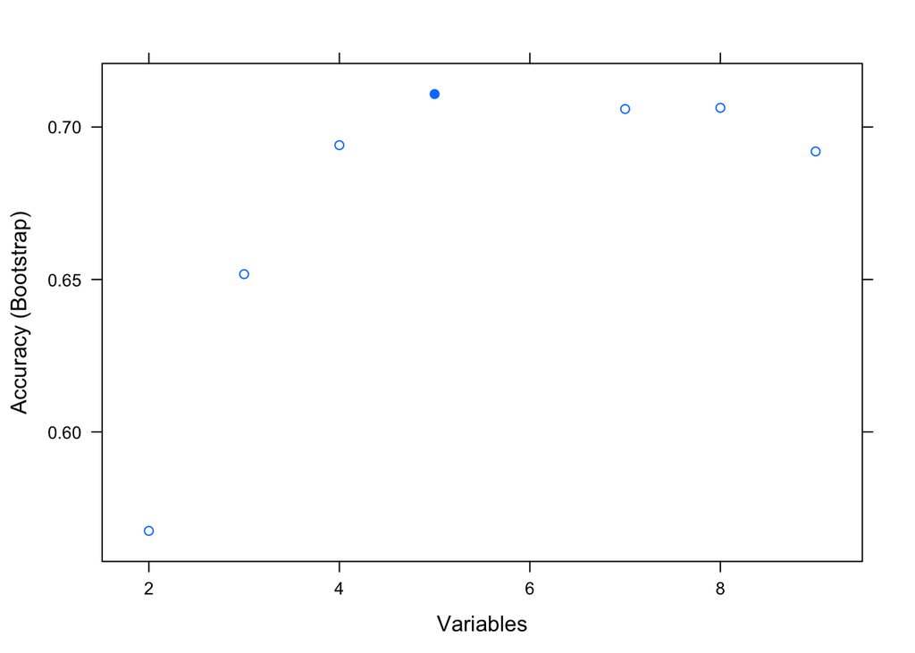

```r
plot(rfe_results)
```

```r
predictors(rfe_results)
```

```
## [1] "Al" "Ba" "Ca" "Fe" "K"
```

```r
glass_num$Type <- placeholder
```

**Although running this code produces an output, I am extremely skeptical of the results. I had to include “warning = FALSE” in this code chunk header because calling rfe() kept throwing an error multiple times per execution that read:** **“There were missing importance values. There may be linear dependencies in your predictor variables.”** **I strongly question these results not only because it selects “Fe” as a variable (which the random forest model results above suggest is not an important variable), but because the variables which are selected as the top 5 most important happen to be the first 5 of the variables listed in alphabetical order.** **I have tried troubleshooting this problem extensively to no avail.**

### Question 2

```r
# Use backward elimination to build a model

# Start with a multinomial model built from all possible variables using "multinom" from the nnet library
multinom_model <- multinom(Type ~ ., data = glass_num)
step(multinom_model, direction = "backward")
```

```
## Start:  AIC=399.49
## Type ~ RI + Na + Mg + Al + Si + K + Ca + Ba + Fe
##
## trying - RI
## trying - Na
## trying - Mg
## trying - Al
## trying - Si
## trying - K
## trying - Ca
## trying - Ba
## trying - Fe
##        Df      AIC
## - RI   45 389.2406
## - Fe   45 392.9725
## - Ca   45 396.3540
## - Si   45 397.2093
## <none> 50 399.4877
## - Na   45 400.9644
## - Ba   45 402.0861
## - Mg   45 403.5087
## - K    45 404.1896
## - Al   45 411.6853
##
## Step:  AIC=389.24
## Type ~ Na + Mg + Al + Si + K + Ca + Ba + Fe
##
## trying - Na
## trying - Mg
## trying - Al
## trying - Si
## trying - K
## trying - Ca
## trying - Ba
## trying - Fe
##        Df      AIC
## - Fe   40 382.3595
## - Ca   40 386.4793
## - Si   40 388.6597
## <none> 45 389.2406
```

[output cut: 28 more lines]

```
##
## trying - Na
## trying - Mg
## trying - Al
## trying - Si
## trying - K
## trying - Ba
##        Df      AIC
## <none> 35 382.2713
## - Si   30 388.2670
## - Ba   30 395.4175
## - K    30 400.7839
## - Na   30 411.5710
## - Al   30 413.0757
## - Mg   30 428.6945
```

```
## Call:
## multinom(formula = Type ~ Na + Mg + Al + Si + K + Ba, data = glass_num)
##
## Coefficients:
##   (Intercept)         Na         Mg        Al         Si            K
## 2    60.09597  0.2119680 -1.6628702  3.925875 -0.8660912    1.4160121
## 3    24.54593  0.8284043 -0.5114786  1.949841 -0.5123385   -0.7185817
## 5    65.00623 -0.6978495 -3.1806092  9.903862 -0.8925010    2.3192513
## 6   -27.60671  5.4534350 -2.9134962 13.949898 -0.7418634 -100.1070523
## 7  -127.65146  3.4690121 -2.7009724  7.198495  1.0264193    3.2091147
##            Ba
## 2  -1.8772534
## 3  -2.5206059
## 5  -4.1847049
## 6 -48.3781718
## 7  -0.7111102
##
## Residual Deviance: 312.2713
## AIC: 382.2713
```

**The result from this backward elimination process in agreement some of the earlier results. For example, the first feature to be eliminated from our model is the refractive index RI. According to the random forest model results, this variable had the highest average decrease in model accuracy when removed from the model. On the other hand, RI also had the some of the highest correlation with other variables, and so maybe its removal makes sense in this respect. The second variable to be removed was iron Fe, which according to the variable importance values from the random forest model above had the lowest impact on model accuracy when removed.**